# Advanced Modeling - Midterm project

### Hierarchical clustering

An alternative technique is to use hierarchical clustering to explore country similarities, allowing for a flexible approach to identifying clusters at different levels.

Many different combinations of distances and linkage methods can be tried out:

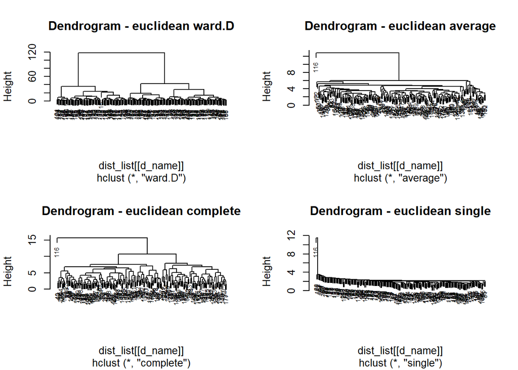

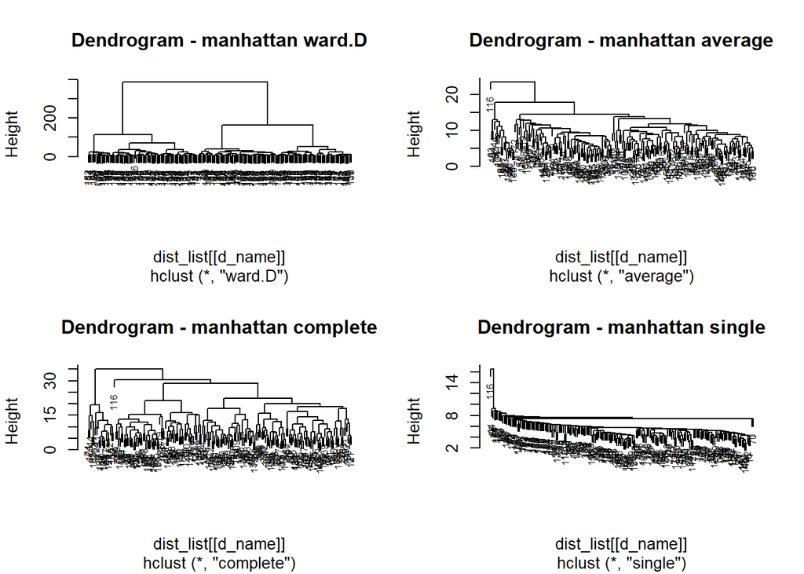

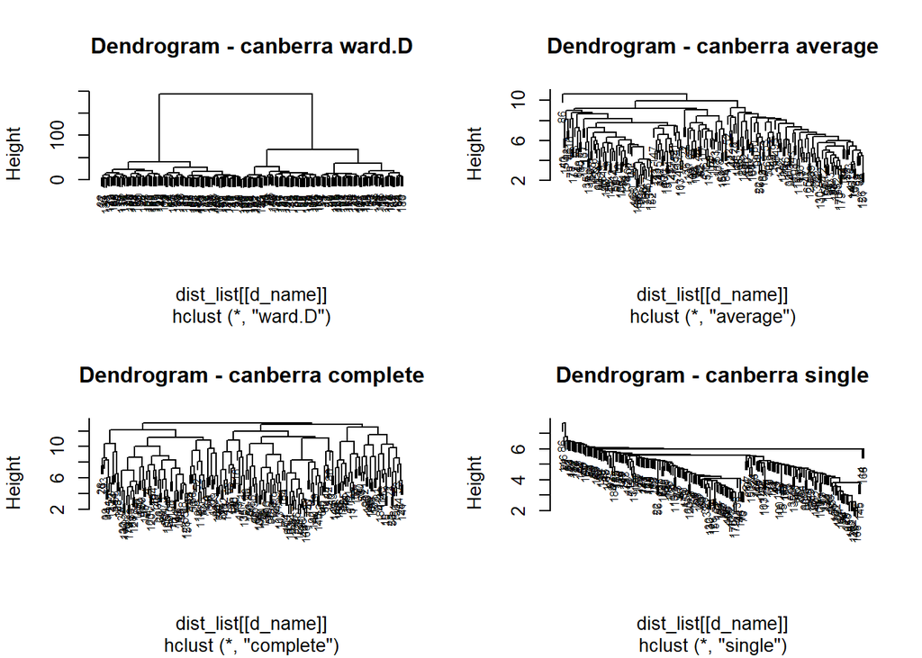

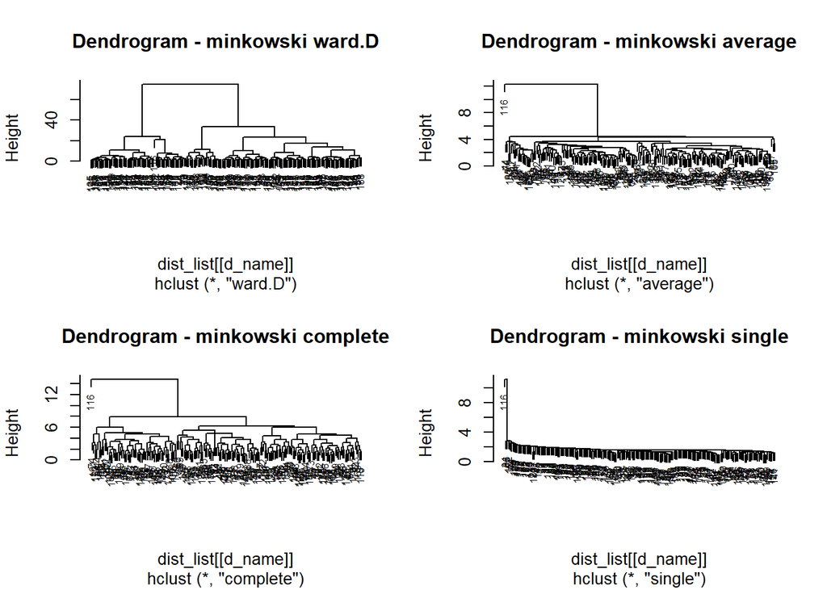

```r
dist_list <- list(
  euclidean = dist(scale(X), method = "euclidean"),
  manhattan = dist(scale(X), method = "manhattan"),
  canberra = dist(scale(X), method = "canberra"),
  minkowski = dist(scale(X), method = "minkowski", p = 3)
)

linkage_methods <- c("ward.D", "average", "complete", "single")

par(mfrow = c(2, 2))
for (d_name in names(dist_list)) {
  for (link in linkage_methods) {
    hc <- hclust(dist_list[[d_name]], method = link)
    plot(hc, main = paste("Dendrogram -", d_name, link), cex = 0.6)
  }
}
```

```r
par(mfrow = c(1, 1))
```

There does not seem to be a single option that stands out or is dramatically more readable than others.

Once we decide on the optimal distance and linkage method, we can carry on with the analysis and different types of visualizations, such as dendograms, cluster plots and phylogenic trees.

Note that we previously decided on an optimal number of groups of 2.

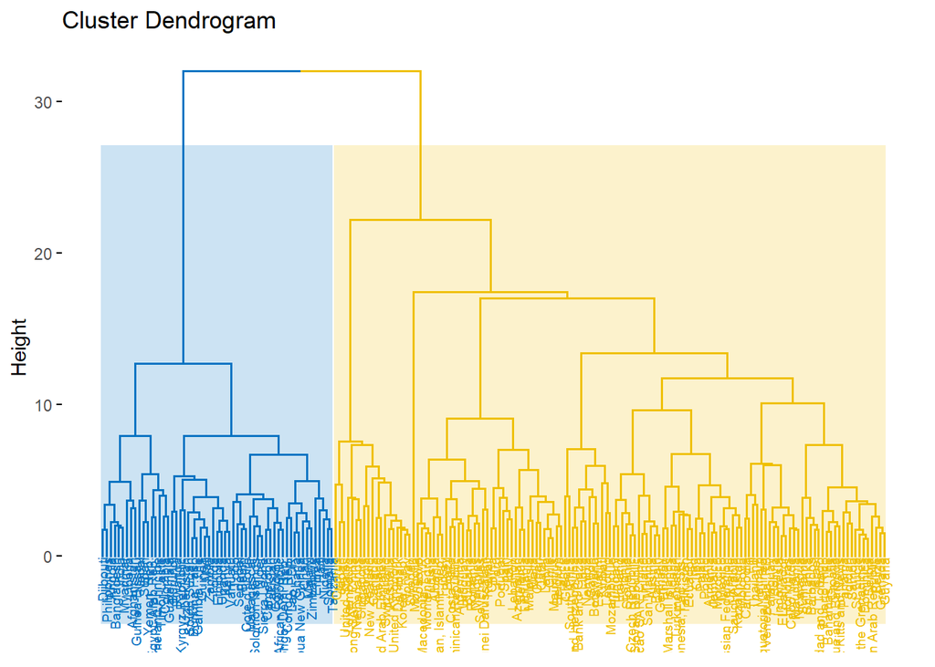

```r
d <- dist(scale(X), method = "euclidean")
hc <- hclust(d, method = "ward.D2")

hc$labels <- id_cols$country_name

# DENDOGRAM
fviz_dend(x = hc,
          k = 2,
          palette = "jco",
          rect = TRUE, rect_fill = TRUE, cex = 0.5,
          rect_border = "jco"
)
```

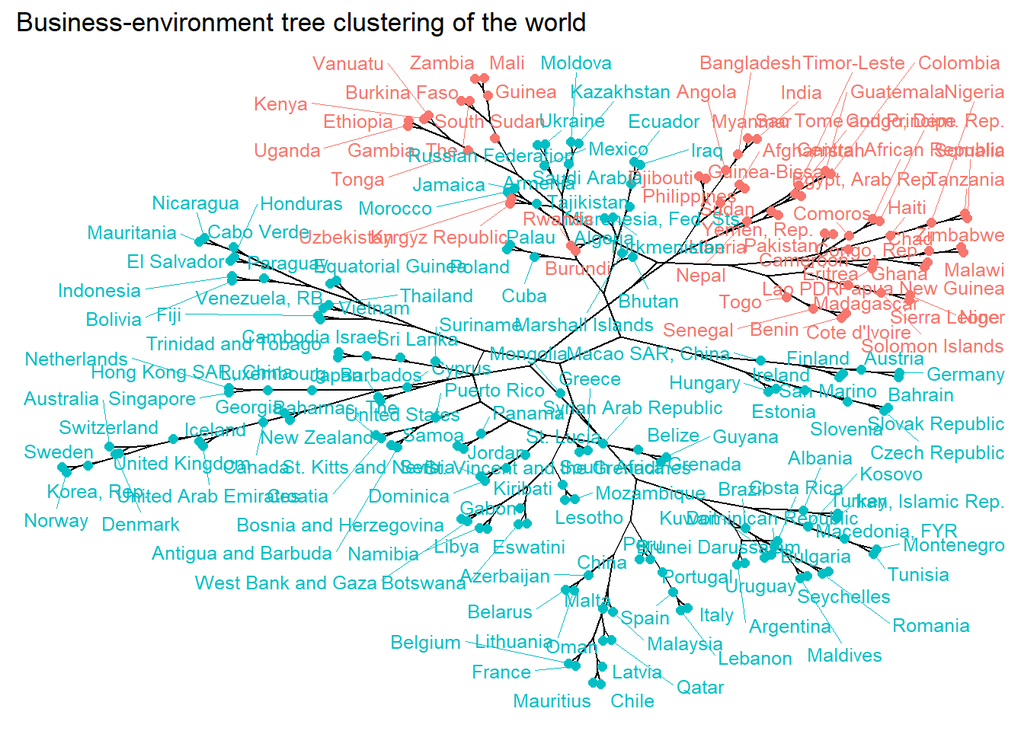

```r
# PHYLOGENIC TREE
fviz_dend(x = hc,
          k = 2,
          color_labels_by_k = TRUE,
          cex = 0.8,
          type = "phylogenic",
          repel = TRUE)+  labs(title = "Business-environment tree clustering of the world") + theme(axis.text.x=element_blank(),axis.text.y=element_blank())
```

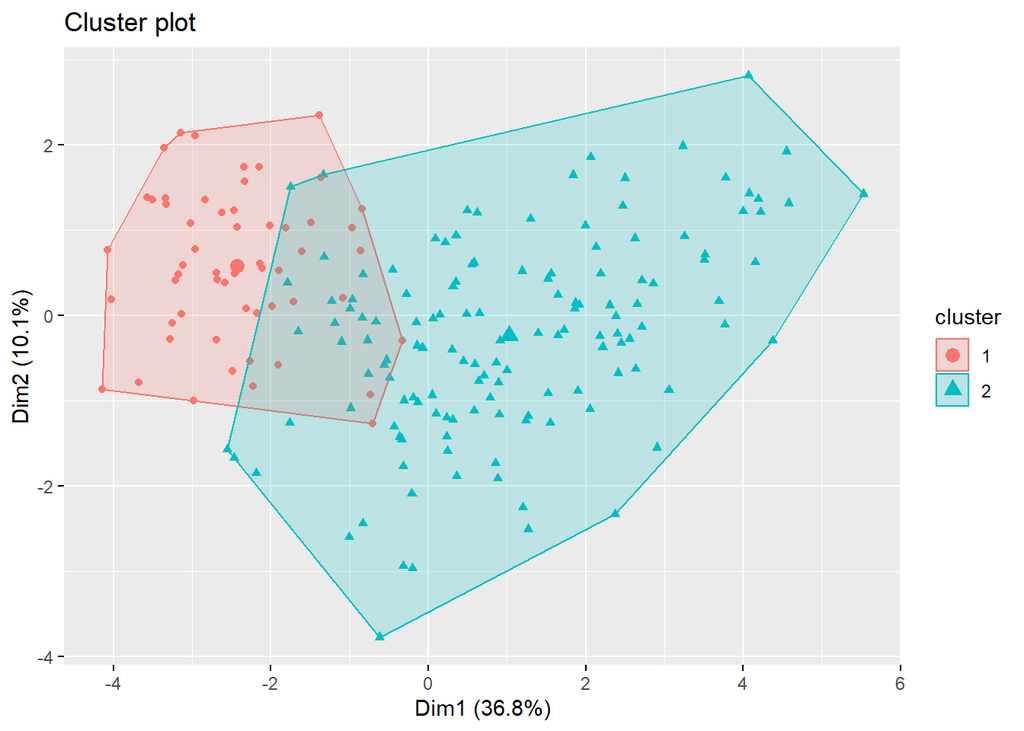

```r
# CLUSTPLOT
clusters_hc <- cutree(hc, k = 2)

fviz_cluster(list(data = scale(X), cluster = clusters_hc), geom = "point")
```

Each of these methods serves for different purposes. For example, the clustering tree allows us to track similarity among observations: countries that branch together have more similar business environments.

The dendogram shows us the several different subclusters that are formed at different heights, indicating the possibility of a multilevel classification.

On another note, the clustplot allows us to check the overlapping, as well as the variability inside each cluster, and the distribution of the observations across dimensions 1 and 2. Cluster 1 (red) countries are positioned primarily in the negative region of Dimension 1, while cluster 2 (blue) countries span from the negative to positive regions of Dimension 1. There’s some separation along Dimension 2 as well, but it’s less pronounced.

It should be noted that, as was mentioned earlier, the proportion of variability captured by these two dimensions is relatively low.

Lastly, we can plot the clustering in a map:

```r
clusters2 <- cutree(hc, k = 2)
table(Cluster = clusters2, Continent = id_cols$continent)
```

```
##        Continent
## Cluster Africa Americas Asia Europe Oceania
##       1     38        3   12      0       4
##       2     16       33   37     41       8
```

```r
map_data <- data.frame(country = id_cols$country_name, cluster = clusters2)

map_data$iso3c <- countrycode(map_data$country, 'country.name', 'iso3c')

matched <- joinCountryData2Map(map_data, joinCode = "ISO3", nameJoinColumn = "iso3c")
```

```
## 191 codes from your data successfully matched countries in the map
## 1 codes from your data failed to match with a country code in the map
## 52 codes from the map weren't represented in your data
```

```
## You asked for 7 categories, 5 were used due to pretty() classification
```

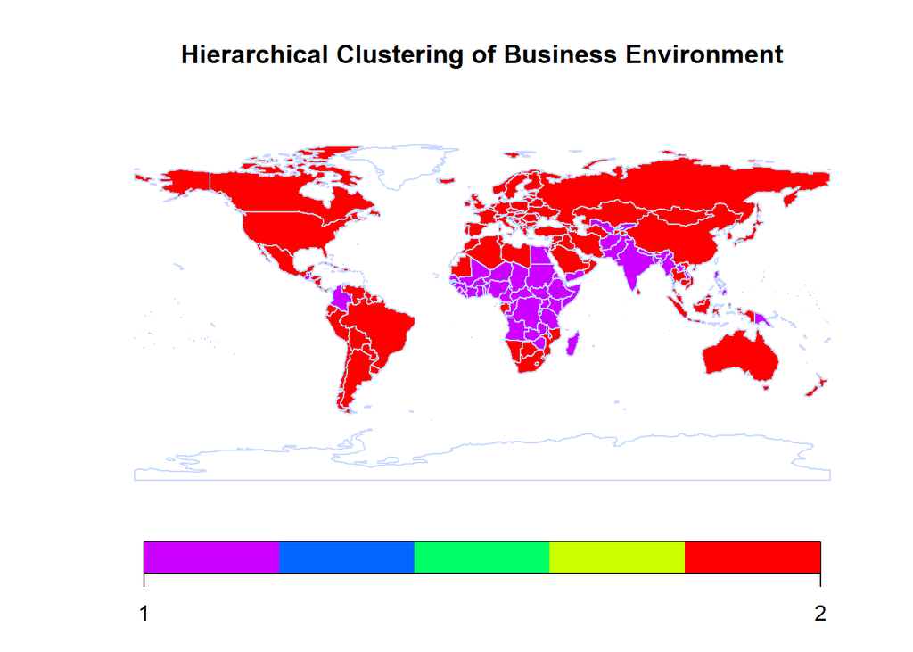

```r
mapCountryData(matched,
               nameColumnToPlot = "cluster",
               missingCountryCol = "white",
               borderCol = "#C7D9FF",
               catMethod = "pretty",
               colourPalette = "rainbow",
               mapTitle = "Hierarchical Clustering of Business Environment",
               lwd = 1)
```

This map allows for a clearer interpretation of geographical patterns: we see that most African nations, as well as some countries in Southern Asia, are colored in purple. One of the most interesting insights is that the nations of North and Southern Africa show traits more similar to those of the more advanced economies, while a wide central belt of the continent remains on the side of the developing economies. On the other end, most developed economies (North America, Europe, Australia, parts of East Asia, the Arabian Peninsula, etc.) are colored in red. The map also shows some interesting outliers, that is, countries that do not cluster with their geographic neighbors, suggesting that the characteristics of the business environment may transcend regional patterns. Colombia might be an example of this, although it is true that it could share more characteristics with its Caribbean neighbors rather than other countries in South America.

## Final considerations

Our analysis aimed to determine whether countries can be classified based on their business dynamism using PCA and clustering techniques.

PCA identified key dimensions of business environments: the first few principal components captured major aspects of business dynamism, such as economic development, financial accessibility, and regulatory efficiency. PCA also showed that 5-6 components were needed in order to capture around 75% of the variability in the dataset. This might point to the fact that business dynamism is influenced by a broad set of factors, or even that some important features were missing from our current selection of variables.

The clustering results revealed meaningful groupings of countries with similar business conditions. Countries with high economic development, strong financial sectors, and streamlined administrative processes tended to cluster together, while those with weaker financial infrastructure and higher administrative burdens formed separate groups.

Ultimately, while the clusters largely align with known economic and regional divisions, there are some outliers: countries that do not fit neatly into one category due to unique financial or regulatory conditions. In some cases, we also observed considerable overlapping, indicating that the division is not always that clear. Ultimately, while broad classifications are feasible, a nuanced approach is needed to fully understand business environments.

Unfortunately, the optimal number of clusters was pretty low (2), suggesting that, despite the diversity of economic environments, countries tend to fall into just a few broad categories when it comes to business dynamism. This probably limits the explanatory power of the analysis to some extent. If only two large groups emerge, this suggests that our variables might not incorporate enough granularity to capture more subtle differences across countries.